# Index

laszlovincze

24 helmikuuta 2017

My page is located at: www.github.com/laszlovincze/IODS-project-2

Regression analysis

Here comes a report of a regression analyses, which focuses on how attitude and three different learning styles affects the success in learning statisstics, assesed in points. The data was collected among students at the UH. After data management, the final dataset contained N = 166 participants. The average age of the participants was somewhat over 25 years; there were 110 female and 56 male participants.

The dependent variable I use the analysis is Points. Theindependent variables were deep, surface and strategic learning styles, and attitudes toward learning. Age and gender were used as control variables.

I performed some t-tests, correlational analyses to check the relevant bivariate relationships. Also, I visualized the bivariate relationsip between the theoretically relevant inndependent variables and points, and checked also how these relatinships differ between male and female students.

I performed at least a dozen regressions with IVs in different combinations and included even interaction terms, but as a matter of fact, none of the models was really interesting. This is pity because I thought that attitudes and learning styles would interact in predicting points… Also, after visualising the data, I expected that the effect of deep learning style on points is moderated by gender; however, it was not the case.

```r
library(readr)
learning14 <- read_csv("F:/IODS-project-2/learning14.csv")
View(learning14)
View(learning14)

str(learning14)
```

```
## Classes 'tbl_df', 'tbl' and 'data.frame':    166 obs. of  7 variables:
##  $ gender  : chr  "F" "M" "F" "M" ...
##  $ Age     : int  53 55 49 53 49 38 50 37 37 42 ...
##  $ Attitude: int  37 31 25 35 37 38 35 29 38 21 ...
##  $ deep    : num  3.75 2.88 3.88 3.5 3.75 ...
##  $ surf    : num  2.58 3.17 2.25 2.25 2.83 ...
##  $ stra    : num  3.38 2.75 3.62 3.12 3.62 ...
##  $ Points  : int  25 12 24 10 22 21 21 31 24 26 ...
##  - attr(*, "spec")=List of 2
##   ..$ cols   :List of 7
##   .. ..$ gender  : list()
##   .. .. ..- attr(*, "class")= chr  "collector_character" "collector"
##   .. ..$ Age     : list()
##   .. .. ..- attr(*, "class")= chr  "collector_integer" "collector"
##   .. ..$ Attitude: list()
##   .. .. ..- attr(*, "class")= chr  "collector_integer" "collector"
##   .. ..$ deep    : list()
##   .. .. ..- attr(*, "class")= chr  "collector_double" "collector"
##   .. ..$ surf    : list()
##   .. .. ..- attr(*, "class")= chr  "collector_double" "collector"
##   .. ..$ stra    : list()
##   .. .. ..- attr(*, "class")= chr  "collector_double" "collector"
##   .. ..$ Points  : list()
##   .. .. ..- attr(*, "class")= chr  "collector_integer" "collector"
##   ..$ default: list()
##   .. ..- attr(*, "class")= chr  "collector_guess" "collector"
##   ..- attr(*, "class")= chr "col_spec"
```

```r
mean(learning14$Age)
```

```
## [1] 25.51205
```

```r
str(learning14$gender)
```

```
##  chr [1:166] "F" "M" "F" "M" "M" "F" "M" "F" "M" ...
```

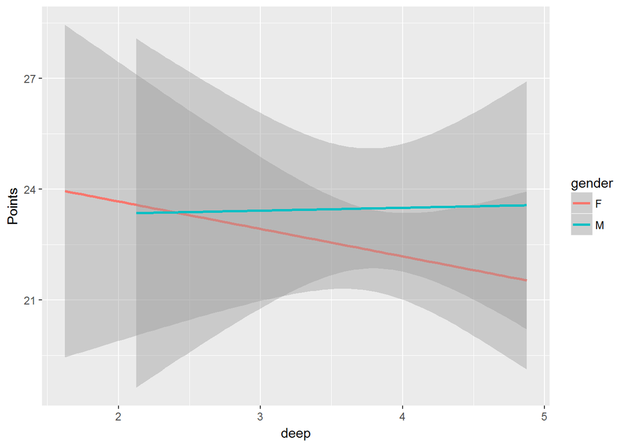

```r
View(learning14$gender)

library(ggplot2)

#I have created a couple of graphs with ggplot2. The first one has appeared to be interesting,
# but only at the first sight (I tested the combined effect of deep and gender on points, and
# it was not different from zero).

plot1a <- ggplot(learning14, aes(x=deep, y=Points, col = gender))
plot1b <- plot1a + geom_smooth(method = "lm")
plot1b
```

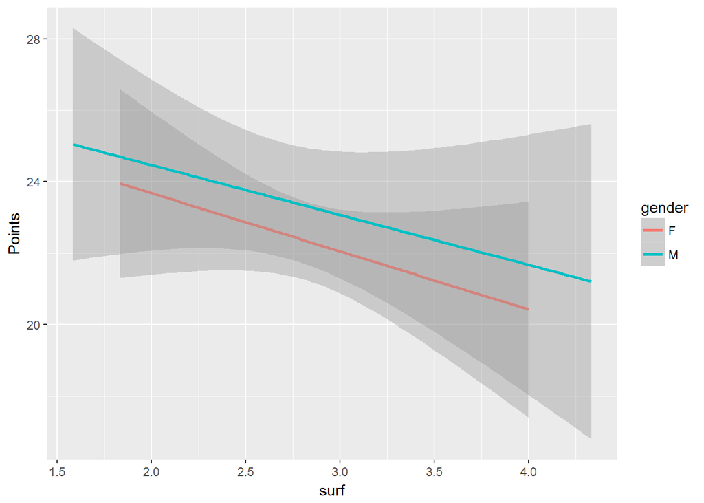

```r
plot2a <- ggplot(learning14, aes(x=surf, y=Points, col = gender))
plot2b <- plot2a + geom_smooth(method = "lm")
plot2b
```

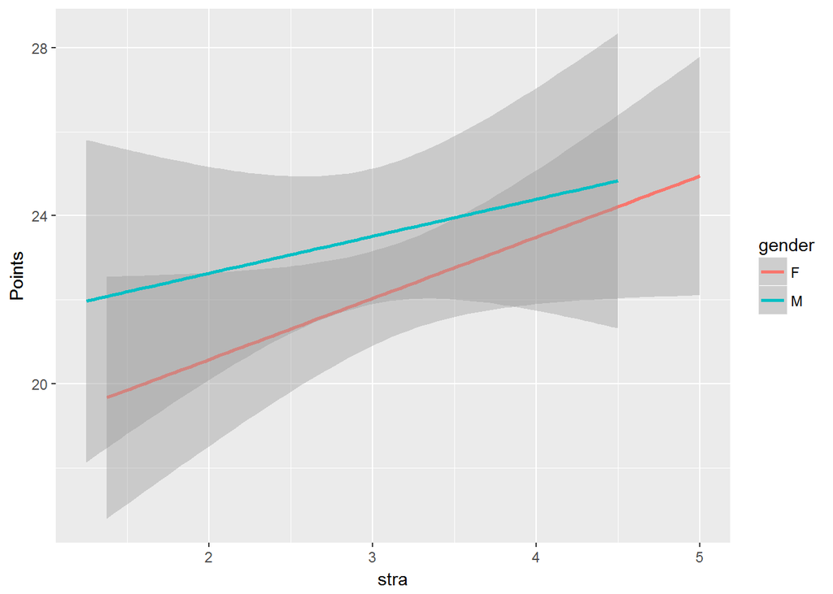

```r
plot3a <- ggplot(learning14, aes(x=stra, y=Points, col = gender))
plot3b <- plot3a + geom_smooth(method = "lm")
plot3b
```

```r
head(learning14)
```

```
## # A tibble: 6 × 7
##   gender   Age Attitude  deep     surf  stra Points
##    <chr> <int>    <int> <dbl>    <dbl> <dbl>  <int>
## 1      F    53       37 3.750 2.583333 3.375     25
## 2      M    55       31 2.875 3.166667 2.750     12
## 3      F    49       25 3.875 2.250000 3.625     24
## 4      M    53       35 3.500 2.250000 3.125     10
## 5      M    49       37 3.750 2.833333 3.625     22
## 6      F    38       38 4.875 2.416667 3.625     21
```

```r
# Also, I have performed a set of bivariate analyses to test the individual effects of
# age, gender and learning attitude on the outcome variable.

cor.test(learning14$Age, learning14$Points)
```

```
##
##  Pearson's product-moment correlation
##
## data:  learning14$Age and learning14$Points
## t = -1.1986, df = 164, p-value = 0.2324
## alternative hypothesis: true correlation is not equal to 0
## 95 percent confidence interval:
##  -0.24207559  0.05998263
## sample estimates:
##         cor
## -0.09319032
```

```r
cor.test(learning14$Attitude, learning14$Points)
```

```
##
##  Pearson's product-moment correlation
##
## data:  learning14$Attitude and learning14$Points
## t = 6.2135, df = 164, p-value = 4.119e-09
## alternative hypothesis: true correlation is not equal to 0
## 95 percent confidence interval:
##  0.3044463 0.5521335
## sample estimates:
##       cor
## 0.4365245
```

```r
t.test(learning14$Points ~ learning14$gender)
```

```
##
##  Welch Two Sample t-test
##
## data:  learning14$Points by learning14$gender
## t = -1.1832, df = 107.84, p-value = 0.2393
## alternative hypothesis: true difference in means is not equal to 0
## 95 percent confidence interval:
##  -3.0896905  0.7799502
## sample estimates:
## mean in group F mean in group M
##        22.32727        23.48214
```

```r
#I performed at least a dozen regressions with IVs in different combinations and included
# interaction terms, but as a matter of fact, none of them was really interesting. This is pity
# because I thought that attitudes and learning styles would interact in predicting points... So I kept
# the following model, where attitude is defined as IV and the model is controlled for gender and age.

model <- lm(learning14$Points ~ learning14$Attitude + learning14$gender + learning14$Age)
summary(model)
```

```
##
## Call:
## lm(formula = learning14$Points ~ learning14$Attitude + learning14$gender +
##     learning14$Age)
##
## Residuals:
##      Min       1Q   Median       3Q      Max
## -17.4590  -3.3221   0.2186   4.0247  10.4632
##
## Coefficients:
##                     Estimate Std. Error t value Pr(>|t|)
## (Intercept)         13.42910    2.29043   5.863 2.48e-08 ***
## learning14$Attitude  0.36066    0.05932   6.080 8.34e-09 ***
## learning14$genderM  -0.33054    0.91934  -0.360    0.720
## learning14$Age      -0.07586    0.05367  -1.414    0.159
## ---
## Signif. codes:  0 '***' 0.001 '**' 0.01 '*' 0.05 '.' 0.1 ' ' 1
##
## Residual standard error: 5.315 on 162 degrees of freedom
## Multiple R-squared:  0.2018, Adjusted R-squared:  0.187
## F-statistic: 13.65 on 3 and 162 DF,  p-value: 5.536e-08
```

```r
# The model was significant, and explained 19 % of the variance in the DV. Positive learning attitudes
# contributed to a better efficiancy in points. Age and gender had no significant effects.

model <- lm(learning14$Points ~ learning14$Attitude + learning14$surf + learning14$stra + learning14$deep)
summary(model)
```

```
##
## Call:
## lm(formula = learning14$Points ~ learning14$Attitude + learning14$surf +
##     learning14$stra + learning14$deep)
##
## Residuals:
##      Min       1Q   Median       3Q      Max
## -16.7802  -3.1579   0.7054   3.3445  11.7950
##
## Coefficients:
##                     Estimate Std. Error t value Pr(>|t|)
## (Intercept)         16.30255    5.03394   3.239  0.00146 **
## learning14$Attitude  0.34085    0.05718   5.961 1.54e-08 ***
## learning14$surf     -0.96523    0.83549  -1.155  0.24969
## learning14$stra      0.89747    0.54012   1.662  0.09854 .
## learning14$deep     -1.16145    0.75749  -1.533  0.12717
## ---
## Signif. codes:  0 '***' 0.001 '**' 0.01 '*' 0.05 '.' 0.1 ' ' 1
##
## Residual standard error: 5.274 on 161 degrees of freedom
## Multiple R-squared:  0.2188, Adjusted R-squared:  0.1994
## F-statistic: 11.28 on 4 and 161 DF,  p-value: 4.323e-08
```

```r
#I added the three learning styles to the model; none of them was significant. therefore I ran a final model, which include
#only attitude as explanatory variable. The model was significant, and explained 19% of the variance
#in the dependent variable, F(1, 164) = 38.61, p <.001. The unsrandardized regression coefficients of attitude was B=.35.
# This can be interpreted as more positive attitudes toward learning resultaed in higher points.

final_model <- lm(learning14$Points ~ learning14$Attitude)
summary(final_model)
```

```
##
## Call:
## lm(formula = learning14$Points ~ learning14$Attitude)
##
## Residuals:
##      Min       1Q   Median       3Q      Max
## -16.9763  -3.2119   0.4339   4.1534  10.6645
##
## Coefficients:
##                     Estimate Std. Error t value Pr(>|t|)
## (Intercept)         11.63715    1.83035   6.358 1.95e-09 ***
## learning14$Attitude  0.35255    0.05674   6.214 4.12e-09 ***
## ---
## Signif. codes:  0 '***' 0.001 '**' 0.01 '*' 0.05 '.' 0.1 ' ' 1
##
## Residual standard error: 5.32 on 164 degrees of freedom
## Multiple R-squared:  0.1906, Adjusted R-squared:  0.1856
## F-statistic: 38.61 on 1 and 164 DF,  p-value: 4.119e-09
```

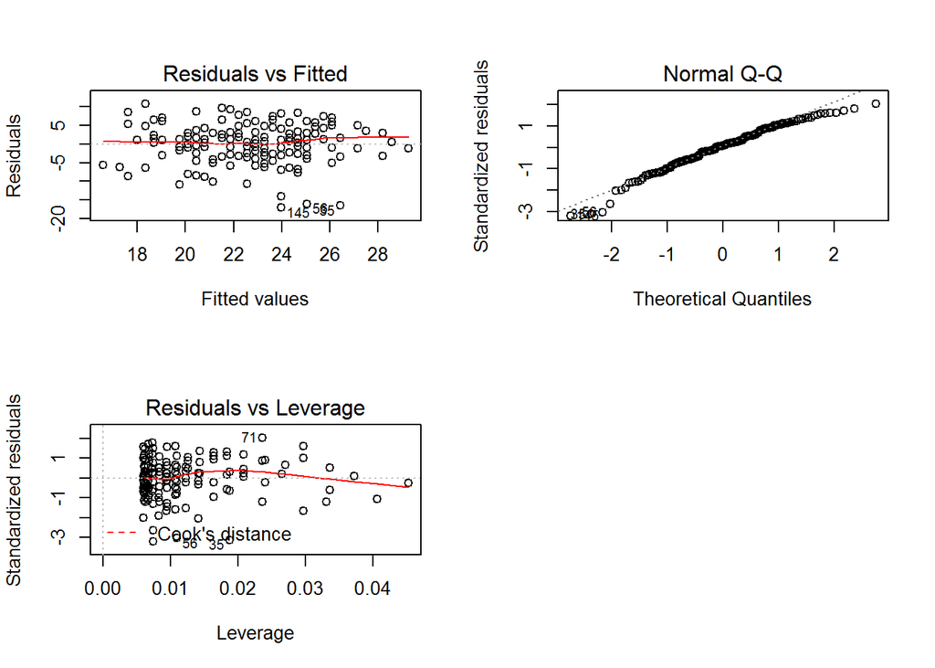

```r
#I created plots to diagnostize model fit. Theere seems to be some violaationn against normality in each plot.
par(mfrow = c(2,2))
plot(final_model, which = c(1, 2, 5))
```

My final model included only attitude as explanatory variable. The model was significant, and explained 19% of the variance in the dependent variable, F(1, 164) = 38.61, p <.001. The unstandardized regression coefficients of attitude was B=.35. This can be interpreted as more positive attitudes toward learning resultaed in higher points. However, I created plots to diagnostize model fit. Theere seems to be some violaationn against normality in each plot.

```r
#First, I read the data from the webpage to R.

library(data.table)

data <- fread('http://s3.amazonaws.com/assets.datacamp.com/production/course_2218/datasets/alc.txt')
str(data)
```

```
## Classes 'data.table' and 'data.frame':   382 obs. of  35 variables:
##  $ school    : chr  "GP" "GP" "GP" "GP" ...
##  $ sex       : chr  "F" "F" "F" "F" ...
##  $ age       : int  18 17 15 15 16 16 16 17 15 15 ...
##  $ address   : chr  "U" "U" "U" "U" ...
##  $ famsize   : chr  "GT3" "GT3" "LE3" "GT3" ...
##  $ Pstatus   : chr  "A" "T" "T" "T" ...
##  $ Medu      : int  4 1 1 4 3 4 2 4 3 3 ...
##  $ Fedu      : int  4 1 1 2 3 3 2 4 2 4 ...
##  $ Mjob      : chr  "at_home" "at_home" "at_home" "health" ...
##  $ Fjob      : chr  "teacher" "other" "other" "services" ...
##  $ reason    : chr  "course" "course" "other" "home" ...
##  $ nursery   : chr  "yes" "no" "yes" "yes" ...
##  $ internet  : chr  "no" "yes" "yes" "yes" ...
##  $ guardian  : chr  "mother" "father" "mother" "mother" ...
```

[output cut: 22 more lines]

```r
dim(data)
```

```
## [1] 382  35
```

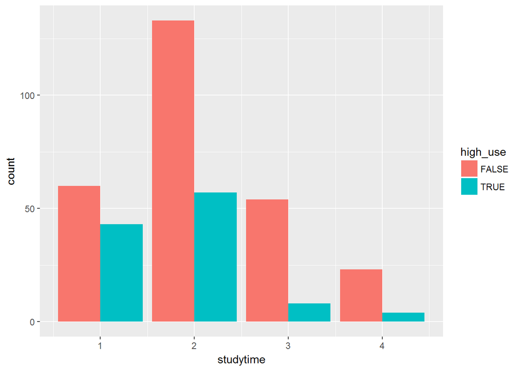

```r
#I chose the following four explanatory variables. The first
#sex        student's sex (binary: 'F' - female or 'M' - male)
#studytime  weekly study time (numeric: 1 - <2 hours, 2 - 2 to 5 hours, 3 - 5 to 10 hours, or 4 - >10 hours)
#health     current health status (numeric: from 1 - very bad to 5 - very good)
#goout  going out with friends (numeric: from 1 - very low to 5 - very high)

#The four hypos are as follows:
#(H1) Males are more often heavy drnkers than females.
#(H2) People spending less time with their studies are more often heavy drinker than the rest.
#(H3) The worse the healt situation, the greater the probability that somebody is a hevay drinker.
#(H4) The more often somebody goes out with his/her friends, the greater the probability that somebody is a hevay drinker.


#I checked the bivariate relationships between the dependent variable and the four explanatory variables
#by the means of plotting and bivariate analyses.
#I read ggplot2.

library(ggplot2)

ggplot(data,aes(x=studytime, fill=high_use)) + geom_bar(position="dodge")
```

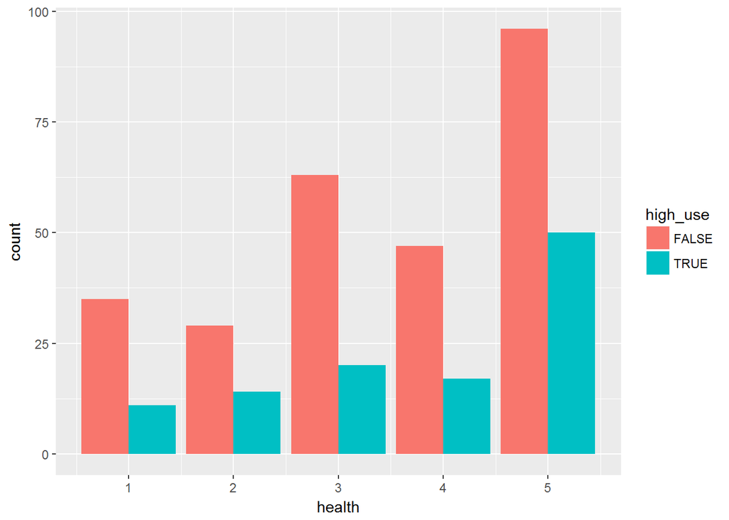

```r
ggplot(data,aes(x=health, fill=high_use)) + geom_bar(position="dodge")
```

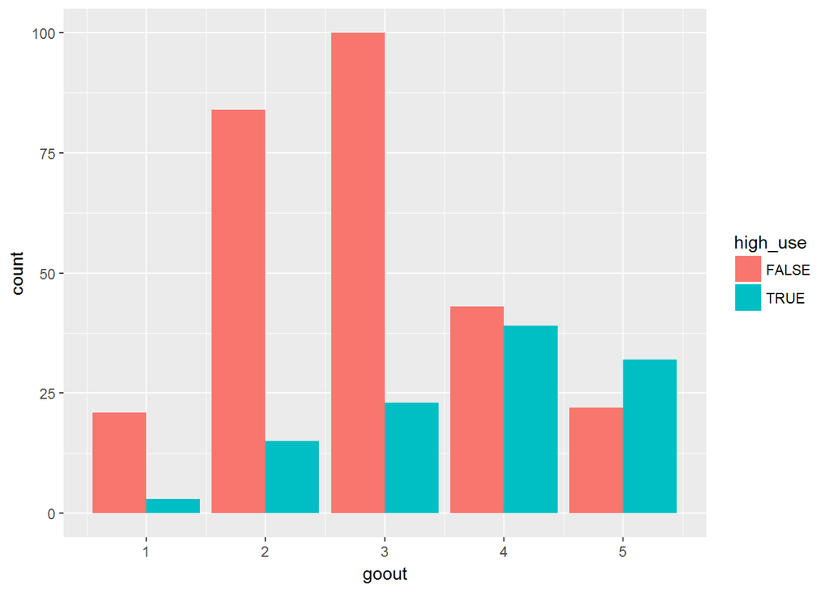

```r
ggplot(data,aes(x=goout, fill=high_use)) + geom_bar(position="dodge")
```

```r
t.test(data$studytime ~ data$high_use)
```

```
##
##  Welch Two Sample t-test
##
## data:  data$studytime by data$high_use
## t = 4.4587, df = 240.46, p-value = 1.266e-05
## alternative hypothesis: true difference in means is not equal to 0
## 95 percent confidence interval:
##  0.2172586 0.5611806
## sample estimates:
## mean in group FALSE  mean in group TRUE
##            2.148148            1.758929
```

```r
t.test(data$health ~ data$high_use)
```

```
##
##  Welch Two Sample t-test
##
## data:  data$health by data$high_use
## t = -1.3032, df = 207.98, p-value = 0.1939
## alternative hypothesis: true difference in means is not equal to 0
## 95 percent confidence interval:
##  -0.5143419  0.1049504
## sample estimates:
## mean in group FALSE  mean in group TRUE
##            3.518519            3.723214
```

```r
t.test(data$goout ~ data$high_use)
```

```
##
##  Welch Two Sample t-test
##
## data:  data$goout by data$high_use
## t = -7.2019, df = 198.31, p-value = 1.206e-11
## alternative hypothesis: true difference in means is not equal to 0
## 95 percent confidence interval:
##  -1.1166124 -0.6365622
## sample estimates:
## mean in group FALSE  mean in group TRUE
##            2.855556            3.732143
```

```r
#Taken together, both the plotting and the t-test indicate that there is no difference in perceived healt
#between the two group, but the difference is remarkable with respect the two other variables. The less somebody
#spends with studying and the more often somebody goes out with friends increase the probability of the person
#is a heavy drinker

#Now I check the role of gender in drinking habits.
tbl = table(data$high_use, data$sex)
prop.table(tbl, 2)
```

```
##
##                 F         M
##   FALSE 0.7929293 0.6141304
##   TRUE  0.2070707 0.3858696
```

```r
chisq.test(tbl)
```

```
##
##  Pearson's Chi-squared test with Yates' continuity correction
##
## data:  tbl
## X-squared = 13.863, df = 1, p-value = 0.0001967
```

```r
#The crosstabulation and the related chi-square analysis indicated that male students are more often
#heavy drinkers than female mstudents.

#Here comes the logistic regression. I open also the rcompanion library to get results about model fit.
library(rcompanion)

log_reg <- glm(high_use ~ sex + health + goout + studytime, data = data, family = "binomial")
summary(log_reg)
```

```
##
## Call:
## glm(formula = high_use ~ sex + health + goout + studytime, family = "binomial",
##     data = data)
##
## Deviance Residuals:
##     Min       1Q   Median       3Q      Max
## -1.7510  -0.8078  -0.5044   0.8624   2.6567
##
## Coefficients:
##             Estimate Std. Error z value Pr(>|z|)
## (Intercept) -3.01856    0.65865  -4.583 4.58e-06 ***
## sexM         0.63809    0.26329   2.424  0.01537 *
## health       0.08162    0.09056   0.901  0.36743
## goout        0.75086    0.11810   6.358 2.04e-10 ***
## studytime   -0.49218    0.16861  -2.919  0.00351 **
## ---
## Signif. codes:  0 '***' 0.001 '**' 0.01 '*' 0.05 '.' 0.1 ' ' 1
##
## (Dispersion parameter for binomial family taken to be 1)
##
##     Null deviance: 462.21  on 381  degrees of freedom
## Residual deviance: 389.24  on 377  degrees of freedom
## AIC: 399.24
##
## Number of Fisher Scoring iterations: 4
```

```r
nagelkerke(log_reg)
```

```
## $Models
##
## Model: "glm, high_use ~ sex + health + goout + studytime, binomial, data"
## Null:  "glm, high_use ~ 1, binomial, data"
##
## $Pseudo.R.squared.for.model.vs.null
##                              Pseudo.R.squared
## McFadden                             0.157879
## Cox and Snell (ML)                   0.173892
## Nagelkerke (Cragg and Uhler)         0.247782
##
## $Likelihood.ratio.test
##  Df.diff LogLik.diff  Chisq    p.value
##       -4     -36.487 72.973 5.3445e-15
##
## $Messages
## [1] "Note: For models fit with REML, these statistics are based on refitting with ML"
```

```r
exp(cbind(OR = coef(log_reg), confint(log_reg)))
```

```
##                     OR      2.5 %    97.5 %
## (Intercept) 0.04887132 0.01298659 0.1728222
## sexM        1.89285515 1.13215292 3.1853333
## health      1.08504296 0.90976983 1.2986339
## goout       2.11882962 1.69152440 2.6902214
## studytime   0.61129440 0.43467779 0.8437448
```

```r
#The model was significant, x2(4) =72.97, p <.001, and accodring to Nagelkerke pseudo R-square
# it explained 25% of the variation in high alcohol consumption. Out of the four explanatory variables
#perceived health state had no significant effect, however, the other three variables explained signifi-
#cantly the dependent variable. Specifically, it was shown that the relative probability that a male is
# heavy drinker is about 1.89 times greater than that a female becomes heavy drinker. The interpretation of the
# the two other explanatory variables is more difficult; basically, increase in goout and decrease in studytime
# results in an increase in the probability that somebody is a heavy drinker (it would have perhaps been better
#to use these variables as ordered categorical, but explaining the efects would have been difficult even so)"


#I created the classification table according to instructions on the R homepage. According to these results,
#76.4% of the cases could be correctly classified by the model.

Yhat <- fitted(log_reg)
thresh <- 0.5
YhatFac <- cut(Yhat, breaks=c(-Inf, thresh, Inf), labels=c("low", "high"))

# contingency table and marginal sums
Class_tab <- table(data$high_use, YhatFac)
addmargins(Class_tab)
```

```
##        YhatFac
##         low high Sum
##   FALSE 251   19 270
##   TRUE   71   41 112
##   Sum   322   60 382
```

```r
sum(diag(Class_tab)) / sum(Class_tab)
```

```
## [1] 0.7643979
```

```r
#I could not draw the plot as the lecture disappeared from Datacamp and I could not follow the instructions.
# Yet, I reveal with the following logistic regression that the effect of going out with friends differs between the two gender.


log_reg2 <- glm(high_use ~ sex*goout + health + goout + studytime, data = data, family = "binomial")
summary(log_reg2)
```

```
##
## Call:
## glm(formula = high_use ~ sex * goout + health + goout + studytime,
##     family = "binomial", data = data)
##
## Deviance Residuals:
##     Min       1Q   Median       3Q      Max
## -2.0353  -0.7500  -0.5440   0.6606   2.3695
##
## Coefficients:
##             Estimate Std. Error z value Pr(>|z|)
## (Intercept) -1.56747    0.76141  -2.059  0.03953 *
## sexM        -2.02378    0.86437  -2.341  0.01921 *
## goout        0.35565    0.16203   2.195  0.02817 *
## health       0.07062    0.09252   0.763  0.44527
## studytime   -0.52520    0.17228  -3.049  0.00230 **
## sexM:goout   0.78433    0.24523   3.198  0.00138 **
## ---
## Signif. codes:  0 '***' 0.001 '**' 0.01 '*' 0.05 '.' 0.1 ' ' 1
##
## (Dispersion parameter for binomial family taken to be 1)
##
##     Null deviance: 462.21  on 381  degrees of freedom
## Residual deviance: 378.59  on 376  degrees of freedom
## AIC: 390.59
##
## Number of Fisher Scoring iterations: 4
```